# CA5

##### Mohammad Sadegh Aghili 810100274

```python
import os
import torch
import random
import numpy as np
from PIL import Image
import torch.nn as nn
import tensorflow as tf
import torch.optim as optim
import torch.nn.functional as F
import matplotlib.pyplot as plt
from torchvision import transforms
from torch.utils.data import DataLoader
from torch.utils.data import Dataset, DataLoader
from sklearn.model_selection import train_test_split
```

```python
!unzip /content/AI-CA5-Dataset.zip -d /content/
```

```python
class BrainTumorDataset(Dataset):
    def __init__(self, root_dir, transform=None, paths=None, labels=None):
        self.root_dir = root_dir
        self.transform = transform
        self.classes = ['notumor', 'glioma', 'meningioma', 'pituitary']

        if paths and labels:
            self.data = list(zip(paths, labels))
        else:
            self.data = self.load_data()

        self.labels = [label for _, label in self.data]

    def load_data(self):
        data = []
        for i, class_name in enumerate(self.classes):
            class_path = os.path.join(self.root_dir, class_name)
            for file_name in os.listdir(class_path):
                img_path = os.path.join(class_path, file_name)
                data.append((img_path, i))
        return data

    def __len__(self):
        return len(self.data)

    def __getitem__(self, idx):
        img_path, label = self.data[idx]
        image = Image.open(img_path).convert("RGB")

        if self.transform:
            image = self.transform(image)

        return image, label
```

```python
root_dir = "/content/AI-CA5-Dataset"

transform = transforms.Compose([
    transforms.Resize((512, 512)),
    transforms.ToTensor(),
    # transforms.Normalize(mean=[0.5, 0.5, 0.5], std=[0.5, 0.5, 0.5]),
])

dataset = BrainTumorDataset(root_dir, transform=transform)

batch_size = 8
dataloader = DataLoader(dataset, batch_size=batch_size, shuffle=True, num_workers=2)
```

## Normalization

Normalization in the context of image processing refers to scaling pixel values to a standardized range. In the case of image data, it is common to normalize pixel values to a range between 0 and 1. This process can have several advantages, but it's essential to consider its implications. Advantages of Normalization:

- ```
    Enhanced Model Convergence:
  ```

  * Normalizing pixel values to a common range (e.g., [0, 1]) helps in achieving faster convergence during the training of neural networks. This is because it avoids issues related to disparate input scales, which can cause slow convergence or convergence to poor local optima.

- ```
    Numerical Stability:
  ```

  * Normalization contributes to numerical stability during training. Neural networks often involve operations that can be sensitive to the scale of input values. Normalization helps in preventing issues like vanishing or exploding gradients.

- ```
    Regularization Effect:
  ```

  * Normalization acts as a form of regularization, which can lead to improved generalization performance of the model. It helps in controlling the scale of the activations, reducing the risk of overfitting. Disadvantages and Considerations:

- ```
    Loss of Original Information:
  ```

  * Normalization may cause a loss of information, especially if the original pixel values carry important domain-specific information. This is a trade-off between standardizing input scales and preserving the uniqueness of the data.

- ```
    Normalization Bias:
  ```

  * Normalization assumes a certain distribution of pixel values, and if the actual distribution deviates significantly, it may introduce bias. Understanding the characteristics of the dataset is crucial to determining the appropriate normalization strategy.

```python
transform = transforms.Compose([
    transforms.Resize((512, 512)),
    transforms.ToTensor(),
    transforms.Normalize(mean=[0.5, 0.5, 0.5], std=[0.5, 0.5, 0.5]),
])
```

## Reasons for Choosing a 80-20 Split:

- ```
    Sufficient Training Data:
  ```

  * Allocating 80% of the data for training provides a relatively large amount of data for the model to learn from. This is especially beneficial for complex models that require a substantial amount of training data.

- ```
    Adequate Test Set:
  ```

  * Reserving 20% for testing allows for a sizable test set to assess the model's generalization performance. A smaller test set may not provide a reliable estimate of the model's ability to generalize to new, unseen data.

- ```
    Common Practice:
  ```

  * An 80-20 split is a widely used and accepted practice in the machine learning community. It strikes a balance between having enough data for training and having a meaningful evaluation on the test set.

(If we have a very large dataset, we might consider increasing the size of the test set, such as using a 90-10 or 95-5 split and if the dataset is relatively small, we might opt for a larger training set, like a 70-30 split. In small datasets, having more samples for training can help mitigate overfitting.)

```python
train_data, test_data = train_test_split(dataset.data, test_size=0.2, random_state=42)

train_paths, train_labels = zip(*train_data)
test_paths, test_labels = zip(*test_data)

# new datasets for training and testing
train_dataset = BrainTumorDataset(root_dir, transform=transform, paths=train_paths, labels=train_labels)
test_dataset = BrainTumorDataset(root_dir, transform=transform, paths=test_paths, labels=test_labels)

# Set up DataLoader for each
train_dataloader = DataLoader(train_dataset, batch_size=batch_size, shuffle=True, num_workers=2)
test_dataloader = DataLoader(test_dataset, batch_size=batch_size, shuffle=False, num_workers=2)
```

## Graph

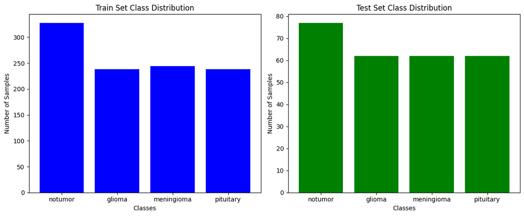

```python
train_class_counts = [0] * len(train_dataset.classes)
for label in train_dataset.labels:
    train_class_counts[label] += 1

test_class_counts = [0] * len(test_dataset.classes)
for label in test_dataset.labels:
    test_class_counts[label] += 1

fig, (ax1, ax2) = plt.subplots(1, 2, figsize=(12, 5))

# Train set
ax1.bar(train_dataset.classes, train_class_counts, color='blue')
ax1.set_title('Train Set Class Distribution')
ax1.set_xlabel('Classes')
ax1.set_ylabel('Number of Samples')

# Test set
ax2.bar(test_dataset.classes, test_class_counts, color='green')
ax2.set_title('Test Set Class Distribution')
ax2.set_xlabel('Classes')
ax2.set_ylabel('Number of Samples')

plt.tight_layout()
plt.show()
```

## Sample Images

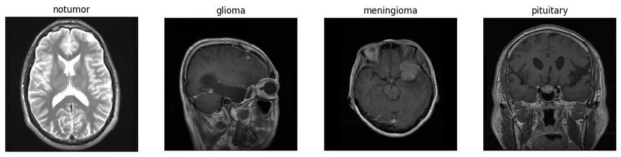

```python
def display_sample_images(dataset, num_samples=1):
    classes = dataset.classes
    fig, axs = plt.subplots(1, len(classes), figsize=(15, 4))

    for i, class_name in enumerate(classes):
        class_indices = [idx for idx, label in enumerate(dataset.labels) if label == i]
        sample_index = random.choice(class_indices)

        img_path, _ = dataset.data[sample_index]
        image = Image.open(img_path).convert("RGB")

        axs[i].imshow(image)
        axs[i].set_title(class_name)
        axs[i].axis('off')

    plt.show()

display_sample_images(train_dataset)
```

## CNN network architecture

```python
class BrainTumorCNN(nn.Module):
    def __init__(self, num_classes=4):
        super(BrainTumorCNN, self).__init__()

        self.conv1 = nn.Conv2d(3, 64, kernel_size=3, stride=1, padding=1)
        self.conv2 = nn.Conv2d(64, 128, kernel_size=3, stride=1, padding=1)
        self.conv3 = nn.Conv2d(128, 256, kernel_size=3, stride=1, padding=1)

        self.pool = nn.MaxPool2d(kernel_size=2, stride=2, padding=0)

        self.fc1 = nn.Linear(256 * 64 * 64, 512)
        self.fc2 = nn.Linear(512, num_classes)

        self.dropout = nn.Dropout(0.5)

    def forward(self, x):
        x = F.relu(self.conv1(x))
        x = self.pool(x)
        x = F.relu(self.conv2(x))
        x = self.pool(x)
        x = F.relu(self.conv3(x))
        x = self.pool(x)

        x = x.view(-1, 256 * 64 * 64)

        x = F.relu(self.fc1(x))
        x = self.dropout(x)
        x = self.fc2(x)

        return x

model = BrainTumorCNN()

print(model)
```

```
BrainTumorCNN(
  (conv1): Conv2d(3, 64, kernel_size=(3, 3), stride=(1, 1), padding=(1, 1))
  (conv2): Conv2d(64, 128, kernel_size=(3, 3), stride=(1, 1), padding=(1, 1))
  (conv3): Conv2d(128, 256, kernel_size=(3, 3), stride=(1, 1), padding=(1, 1))
  (pool): MaxPool2d(kernel_size=2, stride=2, padding=0, dilation=1, ceil_mode=False)
  (fc1): Linear(in_features=1048576, out_features=512, bias=True)
  (fc2): Linear(in_features=512, out_features=4, bias=True)
  (dropout): Dropout(p=0.5, inplace=False)
)
```

### Activaton Function

Activation functions introduce non-linearity to neural networks, allowing them to model complex relationships in the data. Here are some common activation functions and their differences, along with the reasons that I using ReLU in the provided network:

- **ReLU (Rectified Linear Unit):** ReLU sets all negative values to zero and passes positive values unchanged. It is computationally efficient and helps with sparse representations.
- **Sigmoid:** Sigmoid squashes input values to the range (0,1). It's commonly used in the output layer for binary classification.
- **Tanh (Hyperbolic Tangent):** Tanh squashes input values to the range (−1,1). Like sigmoid, it is used in scenarios where values need to be centered around zero.
- **Softmax:** Softmax is used in the output layer for multi-class classification problems. It converts raw scores into probability distributions.
- **Leaky ReLU:** Leaky ReLU allows a small, non-zero gradient for negative inputs, preventing dead neurons.

### Reasons for Using ReLU in the Provided Network:

- Simplicity: ReLU is computationally efficient and easy to implement.
- Non-linearity: ReLU introduces non-linearity, allowing the model to learn complex patterns.
- Addressing Vanishing Gradient: ReLU helps mitigate the vanishing gradient problem, especially in deep networks.
- Sparsity: ReLU promotes sparse representations, making the network more efficient.

## Loss Function

-The most suitable choice for the loss function is the *Cross-Entropy Loss:*

- ```
    Multi-Class Classification:
  ```

  * Cross-Entropy Loss is designed for scenarios where an input can belong to one of several classes. here, we have four classes representing different types of brain tumors.

- ```
    Softmax Activation:
  ```

  * Cross-Entropy Loss pairs well with the softmax activation function. The softmax function is commonly used in the output layer of multi-class classification models to convert raw scores into probability distributions over classes.

- ```
    Optimization Objective:
  ```

  * Minimizing the Cross-Entropy Loss is equivalent to maximizing the likelihood of the training data under the model. This aligns with the goal of training the model to make accurate predictions.

- ```
    Common Practice:
  ```

  * Cross-Entropy Loss is a standard and widely used choice for multi-class classification tasks in the deep learning community. It is effective and well-supported in frameworks like PyTorch.

-Blow are some common loss functions:

- Cross-Entropy Loss (Categorical Cross-Entropy)
- Binary Cross-Entropy Loss
- Mean Squared Error (MSE) Loss
- Hinge Embedding Loss
- Kullback-Leibler Divergence (KL Divergence) Loss

```python
criterion = nn.CrossEntropyLoss()

sample_inputs = torch.randn(32, 3, 512, 512)
sample_labels = torch.randint(0, 4, (32,))

sample_outputs = model(sample_inputs)

sample_loss = criterion(sample_outputs, sample_labels)

print(f'Sample Loss: {sample_loss.item():.4f}')
```

```
Sample Loss: 1.3984
```

## Optimizer

An optimizer is a crucial component in the training process of machine learning models, particularly in the context of neural networks. Its primary function is to minimize the loss function by adjusting the model's parameters during training.

### Adam Optimizer:

#### How Adam Works:

- Adam combines ideas from momentum and RMSprop.
- It maintains two moving averages: mean (mt) and uncentered variance (vt) of gradients.
- Adaptive learning rates for each parameter are computed based on the moving averages.
- Updates include a momentum-like term and a term similar to RMSprop.

#### Differences from SGD:

- Adaptive Learning Rates:
  - Adam adapts learning rates for each parameter individually. It maintains separate learning rates for each parameter based on the past gradients and their square values..
- Momentum-Like Update:
  - Adam includes a momentum-like term (mt) that helps accelerate the optimization process by keeping track of the direction of past gradients. This is similar to the momentum optimizer.
- RMSprop-Like Update:
  - Adam's update formula for the parameters includes a term similar to RMSprop, which normalizes the learning rates by the square root of the exponentially moving average of squared gradients
- Bias Correction:
  - Adam incorporates bias correction for moving averages.

#### Reasons for Using Adam:

- Adaptability:
  - Adjusts learning rates based on individual parameter behavior.
- Robustness:
  - Generally robust and requires less tuning.
- Popular Choice:
  - Widely used in deep learning applications.

```python
def get_adam_optimizer(model, learning_rate=0.008, betas=(0.9, 0.999), epsilon=1e-8):
    return optim.Adam(model.parameters(), lr=learning_rate, betas=betas, eps=epsilon)
```

## Model Training

DataLoader is a utility that helps efficiently load and iterate over batches of data during the training process. It takes care of shuffling the data, dividing it into batches, and loading each batch into the model for training. The DataLoader works seamlessly with datasets like the one you've defined.

Batch Size:

- Batch size is a hyperparameter that determines the number of samples processed in one iteration. It significantly impacts the training process.
- A smaller batch size means the model updates its weights more frequently, and each update is based on a limited set of samples.
- A larger batch size processes more samples at once, updating the weights less frequently.
- The choice of batch size affects the trade-off between computational efficiency and the quality of the weight updates.

```python
# Limit GPU memory usage
config = tf.compat.v1.ConfigProto()
config.gpu_options.per_process_gpu_memory_fraction = 0.85
tf.compat.v1.keras.backend.set_session(tf.compat.v1.Session(config=config))
```

```python
model = model.to('cuda')
```

```
Epoch [1/10], Loss: 77.7217, Accuracy: 0.4599
Epoch [2/10], Loss: 0.7303, Accuracy: 0.7204
Epoch [3/10], Loss: 0.3572, Accuracy: 0.8912
Epoch [4/10], Loss: 0.1898, Accuracy: 0.9427
Epoch [5/10], Loss: 0.0954, Accuracy: 0.9733
Epoch [6/10], Loss: 0.0922, Accuracy: 0.9704
Epoch [7/10], Loss: 0.1030, Accuracy: 0.9723
Epoch [8/10], Loss: 0.0264, Accuracy: 0.9933
Epoch [9/10], Loss: 0.0516, Accuracy: 0.9847
Epoch [10/10], Loss: 0.1267, Accuracy: 0.9771
```

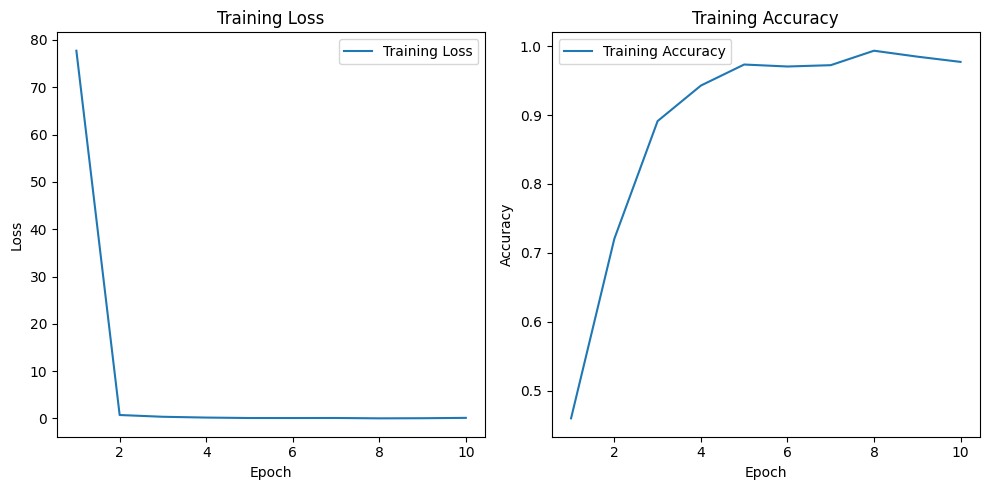

```python
dataloader = train_dataloader
optimizer = get_adam_optimizer(model, learning_rate=0.008, betas=(0.9, 0.999), epsilon=1e-8)


num_epochs = 10
train_losses = []
train_accuracies = []

for epoch in range(num_epochs):
    model.train()
    total_loss = 0
    correct_predictions = 0
    total_samples = 0

    for inputs, labels in dataloader:

        inputs, labels = inputs.to('cuda'), labels.to('cuda')


        optimizer.zero_grad()
        outputs = model(inputs)
        loss = criterion(outputs, labels)
        loss.backward()
        optimizer.step()


        _, predicted = torch.max(outputs, 1)
        correct_predictions += (predicted == labels).sum().item()
        total_samples += labels.size(0)

        total_loss += loss.item()


    epoch_loss = total_loss / len(dataloader)
    epoch_accuracy = correct_predictions / total_samples

    train_losses.append(epoch_loss)
    train_accuracies.append(epoch_accuracy)

    print(f'Epoch [{epoch+1}/{num_epochs}], Loss: {epoch_loss:.4f}, Accuracy: {epoch_accuracy:.4f}')


plt.figure(figsize=(10, 5))
plt.subplot(1, 2, 1)
plt.plot(range(1, num_epochs+1), train_losses, label='Training Loss')
plt.title('Training Loss')
plt.xlabel('Epoch')
plt.ylabel('Loss')
plt.legend()

plt.subplot(1, 2, 2)
plt.plot(range(1, num_epochs+1), train_accuracies, label='Training Accuracy')
plt.title('Training Accuracy')
plt.xlabel('Epoch')
plt.ylabel('Accuracy')
plt.legend()

plt.tight_layout()
plt.show()
```

## Effect of regularization methods on model training

### Dropout:

-Dropout is a regularization technique used during training in neural networks to prevent overfitting. The idea behind dropout is to randomly deactivate (drop out) a certain percentage of neurons in each layer during each forward and backward pass. This helps to prevent the network from relying too much on specific neurons and forces it to learn more robust features:

- During each training iteration, a random subset of neurons in a layer is set to zero (deactivated) with a probability p.
- The probability p is a hyperparameter that determines the fraction of neurons to drop out. A common value is 0.5.
- During the inference or testing phase, all neurons are used, but their weights are scaled by 1-p to maintain the expected output magnitude.

### Batch Normalization:

-Batch Normalization is another regularization technique that addresses internal covariate shift, leading to more stable and faster training of neural networks. Internal covariate shift occurs when the distribution of inputs to a layer changes during training, making it challenging for the network to learn effectively.

- For each mini-batch during training, batch normalization normalizes the inputs by subtracting the mini-batch mean and dividing by the mini-batch standard deviation.
- It helps in maintaining a consistent distribution of inputs, reducing internal covariate shift.
- The normalized inputs are then scaled by a learnable parameter (gamma) and shifted by another learnable parameter (beta).
- This introduces flexibility, allowing the network to learn the optimal scale and shift for each feature.

```
Epoch [1/10], Loss: 0.4952, Accuracy: 0.9380
Epoch [2/10], Loss: 0.6600, Accuracy: 0.9094
Epoch [3/10], Loss: 0.1096, Accuracy: 0.9723
Epoch [4/10], Loss: 0.0492, Accuracy: 0.9847
Epoch [5/10], Loss: 0.1336, Accuracy: 0.9761
Epoch [6/10], Loss: 0.1010, Accuracy: 0.9809
Epoch [7/10], Loss: 0.0277, Accuracy: 0.9895
Epoch [8/10], Loss: 0.0506, Accuracy: 0.9857
Epoch [9/10], Loss: 1.4144, Accuracy: 0.7710
Epoch [10/10], Loss: 1.7206, Accuracy: 0.2815
```

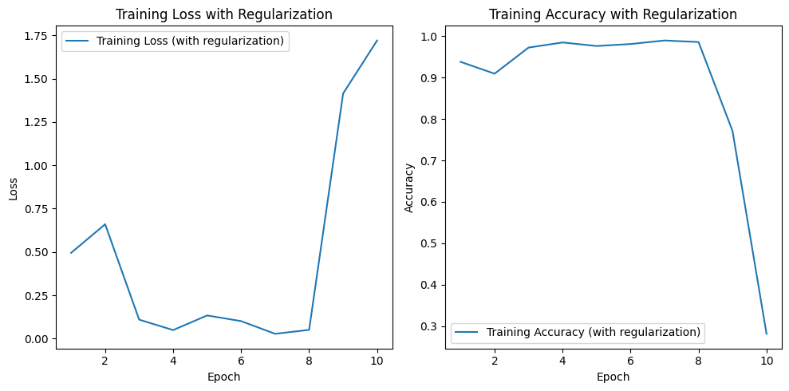

```python
class BrainTumorCNNWithRegularization(nn.Module):
    def __init__(self, num_classes=4, dropout_rate=0.5):
        super(BrainTumorCNNWithRegularization, self).__init__()

        self.conv1 = nn.Conv2d(3, 64, kernel_size=3, stride=1, padding=1)
        self.bn1 = nn.BatchNorm2d(64)
        self.conv2 = nn.Conv2d(64, 128, kernel_size=3, stride=1, padding=1)
        self.bn2 = nn.BatchNorm2d(128)
        self.conv3 = nn.Conv2d(128, 256, kernel_size=3, stride=1, padding=1)
        self.bn3 = nn.BatchNorm2d(256)

        self.pool = nn.MaxPool2d(kernel_size=2, stride=2, padding=0)

        self.fc1 = nn.Linear(256 * 64 * 64, 512)
        self.dropout = nn.Dropout(dropout_rate)
        self.fc2 = nn.Linear(512, num_classes)

    def forward(self, x):
        x = F.relu(self.bn1(self.conv1(x)))
        x = self.pool(x)
        x = F.relu(self.bn2(self.conv2(x)))
        x = self.pool(x)
        x = F.relu(self.bn3(self.conv3(x)))
        x = self.pool(x)

        x = x.view(-1, 256 * 64 * 64)

        x = F.relu(self.fc1(x))
        x = self.dropout(x)
        x = self.fc2(x)

        return x


model_with_regularization = BrainTumorCNNWithRegularization()

criterion = nn.CrossEntropyLoss()
optimizer = get_adam_optimizer(model, learning_rate=0.008, betas=(0.9, 0.999), epsilon=1e-8)

model_with_regularization = model.to('cuda')


num_epochs = 10
train_losses_with_regularization = []
train_accuracies_with_regularization = []

for epoch in range(num_epochs):
    model_with_regularization.train()
    total_loss = 0
    correct_predictions = 0
    total_samples = 0

    for inputs, labels in train_dataloader:
        inputs, labels = inputs.to('cuda'), labels.to('cuda')

        optimizer.zero_grad()
        outputs = model_with_regularization(inputs)
        loss = criterion(outputs, labels)
        loss.backward()
        optimizer.step()


        _, predicted = torch.max(outputs, 1)
        correct_predictions += (predicted == labels).sum().item()
        total_samples += labels.size(0)
        total_loss += loss.item()

    epoch_loss = total_loss / len(train_dataloader)
    epoch_accuracy = correct_predictions / total_samples

    train_losses_with_regularization.append(epoch_loss)
    train_accuracies_with_regularization.append(epoch_accuracy)

    print(f'Epoch [{epoch+1}/{num_epochs}], Loss: {epoch_loss:.4f}, Accuracy: {epoch_accuracy:.4f}')


plt.figure(figsize=(10, 5))
plt.subplot(1, 2, 1)
plt.plot(range(1, num_epochs+1), train_losses_with_regularization, label='Training Loss (with regularization)')
plt.title('Training Loss with Regularization')
plt.xlabel('Epoch')
plt.ylabel('Loss')
plt.legend()

plt.subplot(1, 2, 2)
plt.plot(range(1, num_epochs+1), train_accuracies_with_regularization, label='Training Accuracy (with regularization)')
plt.title('Training Accuracy with Regularization')
plt.xlabel('Epoch')
plt.ylabel('Accuracy')
plt.legend()

plt.tight_layout()
plt.show()
```

## Evaluation and analysis of results

```python
from sklearn.metrics import accuracy_score, precision_score, recall_score, f1_score, confusion_matrix
import seaborn as sns


model_with_regularization.eval()

all_predictions = []
all_labels = []

with torch.no_grad():
    for inputs, labels in test_dataloader:
        inputs, labels = inputs.to('cuda'), labels.to('cuda')

        outputs = model_with_regularization(inputs)

        _, predicted = torch.max(outputs, 1)

        all_predictions.extend(predicted.cpu().numpy())
        all_labels.extend(labels.cpu().numpy())

accuracy = accuracy_score(all_labels, all_predictions)
precision = precision_score(all_labels, all_predictions, average='macro')
recall = recall_score(all_labels, all_predictions, average='macro')
f1 = f1_score(all_labels, all_predictions, average='macro')

print(f"Accuracy: {accuracy:.4f}")
print(f"Precision: {precision:.4f}")
print(f"Recall: {recall:.4f}")
print(f"F1 Score: {f1:.4f}")

# cm = confusion_matrix(all_labels, all_predictions)
# plt.figure(figsize=(6, 4))
# sns.heatmap(cm, annot=True, fmt="d", cmap="Blues", xticklabels=train_dataset.classes, yticklabels=train_dataset.classes)
# plt.title("Confusion Matrix")
# plt.xlabel("Predicted Labels")
# plt.ylabel("True Labels")
# plt.show()
```

```
Accuracy: 0.2928
Precision: 0.0732
Recall: 0.2500
F1 Score: 0.1132
```